# Supervised_Learning_Project

```python
import numpy             as np
import pandas            as pd
import scipy.stats       as stats
import seaborn           as sns
import matplotlib.pyplot as plt
import plotly.express    as px

%matplotlib inline

from sklearn.linear_model import LinearRegression, LogisticRegression
from sklearn.model_selection import train_test_split
from sklearn.neighbors import KNeighborsClassifier
from sklearn.metrics import accuracy_score, confusion_matrix, classification_report
from sklearn.naive_bayes import GaussianNB
from sklearn.svm import SVC
from sklearn import model_selection

from imblearn.over_sampling import RandomOverSampler
from imblearn.over_sampling import SMOTENC
from imblearn.over_sampling import SMOTE

from scipy.stats import zscore
from sklearn import svm
```

### Part A - 30 Marks

1. Data Understanding: [5 Marks]

A. Read all the 3 CSV files as DataFrame and store them into 3 separate variables. [1 Mark]

```python
df_normal = pd.read_csv('Part1 - Normal.csv')
```

```python
df_typeH = pd.read_csv('Part1 - Type_H.csv')
```

```python
df_typeS = pd.read_csv('Part1 - Type_S.csv')
```

```python
df_normal.head()
```

|  | P_incidence | P_tilt | L_angle | S_slope | P_radius | S_Degree | Class |
| --- | --- | --- | --- | --- | --- | --- | --- |
| 0 | 38.505273 | 16.964297 | 35.112814 | 21.540976 | 127.632875 | 7.986683 | Normal |
| 1 | 54.920858 | 18.968430 | 51.601455 | 35.952428 | 125.846646 | 2.001642 | Normal |
| 2 | 44.362490 | 8.945435 | 46.902096 | 35.417055 | 129.220682 | 4.994195 | Normal |
| 3 | 48.318931 | 17.452121 | 48.000000 | 30.866809 | 128.980308 | -0.910941 | Normal |
| 4 | 45.701789 | 10.659859 | 42.577846 | 35.041929 | 130.178314 | -3.388910 | Normal |

```python
df_typeH.head()
```

|  | P_incidence | P_tilt | L_angle | S_slope | P_radius | S_Degree | Class |
| --- | --- | --- | --- | --- | --- | --- | --- |
| 0 | 63.027817 | 22.552586 | 39.609117 | 40.475232 | 98.672917 | -0.254400 | Type_H |
| 1 | 39.056951 | 10.060991 | 25.015378 | 28.995960 | 114.405425 | 4.564259 | Type_H |
| 2 | 68.832021 | 22.218482 | 50.092194 | 46.613539 | 105.985135 | -3.530317 | Type_H |
| 3 | 69.297008 | 24.652878 | 44.311238 | 44.644130 | 101.868495 | 11.211523 | Type_H |
| 4 | 49.712859 | 9.652075 | 28.317406 | 40.060784 | 108.168725 | 7.918501 | Type_H |

```python
df_typeS.head()
```

|  | P_incidence | P_tilt | L_angle | S_slope | P_radius | S_Degree | Class |
| --- | --- | --- | --- | --- | --- | --- | --- |
| 0 | 74.377678 | 32.053104 | 78.772013 | 42.324573 | 143.560690 | 56.125906 | Type_S |
| 1 | 89.680567 | 32.704435 | 83.130732 | 56.976132 | 129.955476 | 92.027277 | Type_S |
| 2 | 44.529051 | 9.433234 | 52.000000 | 35.095817 | 134.711772 | 29.106575 | Type_S |
| 3 | 77.690577 | 21.380645 | 64.429442 | 56.309932 | 114.818751 | 26.931841 | Type_S |
| 4 | 76.147212 | 21.936186 | 82.961502 | 54.211027 | 123.932010 | 10.431972 | Type_S |

B. Print Shape and columns of all the 3 DataFrames. [1 Mark]

```python
df_normal.shape
```

```
(100, 7)
```

```python
df_typeH.shape
```

```
(60, 7)
```

```python
df_typeS.shape
```

```
(150, 7)
```

```python
df_normal.columns
```

```
Index(['P_incidence', 'P_tilt', 'L_angle', 'S_slope', 'P_radius', 'S_Degree',
       'Class'],
      dtype='object')
```

```python
df_typeH.columns
```

```
Index(['P_incidence', 'P_tilt', 'L_angle', 'S_slope', 'P_radius', 'S_Degree',
       'Class'],
      dtype='object')
```

```python
df_typeS.columns
```

```
Index(['P_incidence', 'P_tilt', 'L_angle', 'S_slope', 'P_radius', 'S_Degree',
       'Class'],
      dtype='object')
```

```python
df_normal.info()
```

```
<class 'pandas.core.frame.DataFrame'>
RangeIndex: 100 entries, 0 to 99
Data columns (total 7 columns):
 #   Column       Non-Null Count  Dtype
---  ------       --------------  -----
 0   P_incidence  100 non-null    float64
 1   P_tilt       100 non-null    float64
 2   L_angle      100 non-null    float64
 3   S_slope      100 non-null    float64
 4   P_radius     100 non-null    float64
 5   S_Degree     100 non-null    float64
 6   Class        100 non-null    object
dtypes: float64(6), object(1)
memory usage: 5.6+ KB
```

```python
df_typeH.info()
```

```
<class 'pandas.core.frame.DataFrame'>
RangeIndex: 60 entries, 0 to 59
Data columns (total 7 columns):
 #   Column       Non-Null Count  Dtype
---  ------       --------------  -----
 0   P_incidence  60 non-null     float64
 1   P_tilt       60 non-null     float64
 2   L_angle      60 non-null     float64
 3   S_slope      60 non-null     float64
 4   P_radius     60 non-null     float64
 5   S_Degree     60 non-null     float64
 6   Class        60 non-null     object
dtypes: float64(6), object(1)
memory usage: 3.4+ KB
```

```python
df_typeS.info()
```

```
<class 'pandas.core.frame.DataFrame'>
RangeIndex: 150 entries, 0 to 149
Data columns (total 7 columns):
 #   Column       Non-Null Count  Dtype
---  ------       --------------  -----
 0   P_incidence  150 non-null    float64
 1   P_tilt       150 non-null    float64
 2   L_angle      150 non-null    float64
 3   S_slope      150 non-null    float64
 4   P_radius     150 non-null    float64
 5   S_Degree     150 non-null    float64
 6   Class        150 non-null    object
dtypes: float64(6), object(1)
memory usage: 8.3+ KB
```

```python
df_normal.describe()
```

|  | P_incidence | P_tilt | L_angle | S_slope | P_radius | S_Degree |
| --- | --- | --- | --- | --- | --- | --- |
| count | 100.000000 | 100.000000 | 100.000000 | 100.000000 | 100.000000 | 100.000000 |
| mean | 51.685244 | 12.821414 | 43.542605 | 38.863830 | 123.890834 | 2.186572 |
| std | 12.368161 | 6.778503 | 12.361388 | 9.624004 | 9.014246 | 6.307483 |
| min | 30.741938 | -5.845994 | 19.071075 | 17.386972 | 100.501192 | -11.058179 |
| 25% | 42.817849 | 8.799951 | 35.000000 | 32.340487 | 118.182659 | -1.511360 |
| 50% | 50.123115 | 13.482435 | 42.638923 | 37.059694 | 123.874328 | 1.152710 |
| 75% | 61.470097 | 16.785953 | 51.602346 | 44.608788 | 129.040401 | 4.968807 |
| max | 89.834676 | 29.894119 | 90.563461 | 67.195460 | 147.894637 | 31.172767 |

```python
df_typeH.describe()
```

|  | P_incidence | P_tilt | L_angle | S_slope | P_radius | S_Degree |
| --- | --- | --- | --- | --- | --- | --- |
| count | 60.000000 | 60.000000 | 60.000000 | 60.000000 | 60.000000 | 60.000000 |
| mean | 47.638407 | 17.398795 | 35.463524 | 30.239612 | 116.474968 | 2.480251 |
| std | 10.697131 | 7.016708 | 9.767795 | 7.555388 | 9.355720 | 5.531177 |
| min | 26.147921 | 3.144669 | 14.000000 | 13.366931 | 84.241415 | -10.675871 |
| 25% | 41.018099 | 12.874329 | 29.038069 | 25.215275 | 112.280320 | -0.910819 |
| 50% | 46.416169 | 16.949285 | 35.164873 | 30.000659 | 116.696146 | 2.542441 |
| 75% | 53.922329 | 22.002980 | 42.011563 | 34.962103 | 122.042999 | 6.059666 |
| max | 74.433593 | 41.557331 | 62.275275 | 46.613539 | 137.540613 | 15.779697 |

```python
df_typeS.describe()
```

|  | P_incidence | P_tilt | L_angle | S_slope | P_radius | S_Degree |
| --- | --- | --- | --- | --- | --- | --- |
| count | 150.000000 | 150.000000 | 150.000000 | 150.000000 | 150.000000 | 150.000000 |
| mean | 71.514224 | 20.748038 | 64.110108 | 50.766186 | 114.518810 | 51.896687 |
| std | 15.109337 | 11.506169 | 16.397068 | 12.318813 | 15.579995 | 40.108030 |
| min | 37.903910 | -6.554948 | 24.710274 | 19.290046 | 70.082575 | 1.010041 |
| 25% | 60.658136 | 13.461149 | 52.000000 | 43.166815 | 104.706761 | 30.393271 |
| 50% | 72.149306 | 19.309548 | 62.555200 | 50.751695 | 114.842400 | 42.372509 |
| 75% | 81.075893 | 29.229680 | 76.990924 | 56.675435 | 123.337307 | 61.894425 |
| max | 129.834041 | 49.431864 | 125.742385 | 121.429566 | 163.071041 | 418.543082 |

C. Compare Column names of all the 3 DataFrames and clearly write observations. [1 Mark]

```python
df_normal['matching_cols'] = df_normal.apply(lambda x: x.P_incidence == x.P_tilt == x.L_angle == x.S_slope == x.P_radius == x.S_Degree == x.Class, axis = 1)
df_normal.head()
```

|  | P_incidence | P_tilt | L_angle | S_slope | P_radius | S_Degree | Class | matching_cols |
| --- | --- | --- | --- | --- | --- | --- | --- | --- |
| 0 | 38.505273 | 16.964297 | 35.112814 | 21.540976 | 127.632875 | 7.986683 | Normal | False |
| 1 | 54.920858 | 18.968430 | 51.601455 | 35.952428 | 125.846646 | 2.001642 | Normal | False |
| 2 | 44.362490 | 8.945435 | 46.902096 | 35.417055 | 129.220682 | 4.994195 | Normal | False |
| 3 | 48.318931 | 17.452121 | 48.000000 | 30.866809 | 128.980308 | -0.910941 | Normal | False |
| 4 | 45.701789 | 10.659859 | 42.577846 | 35.041929 | 130.178314 | -3.388910 | Normal | False |

```python
df_typeH['matching_cols'] = df_typeH.apply(lambda x: x.P_incidence == x.P_tilt == x.L_angle == x.S_slope == x.P_radius == x.S_Degree == x.Class, axis = 1)
df_typeH.head()
```

|  | P_incidence | P_tilt | L_angle | S_slope | P_radius | S_Degree | Class | matching_cols |
| --- | --- | --- | --- | --- | --- | --- | --- | --- |
| 0 | 63.027817 | 22.552586 | 39.609117 | 40.475232 | 98.672917 | -0.254400 | Type_H | False |
| 1 | 39.056951 | 10.060991 | 25.015378 | 28.995960 | 114.405425 | 4.564259 | Type_H | False |
| 2 | 68.832021 | 22.218482 | 50.092194 | 46.613539 | 105.985135 | -3.530317 | Type_H | False |
| 3 | 69.297008 | 24.652878 | 44.311238 | 44.644130 | 101.868495 | 11.211523 | Type_H | False |
| 4 | 49.712859 | 9.652075 | 28.317406 | 40.060784 | 108.168725 | 7.918501 | Type_H | False |

```python
df_typeS['matching_cols'] = df_typeS.apply(lambda x: x.P_incidence == x.P_tilt == x.L_angle == x.S_slope == x.P_radius == x.S_Degree == x.Class, axis = 1)
df_typeS.head()
```

|  | P_incidence | P_tilt | L_angle | S_slope | P_radius | S_Degree | Class | matching_cols |
| --- | --- | --- | --- | --- | --- | --- | --- | --- |
| 0 | 74.377678 | 32.053104 | 78.772013 | 42.324573 | 143.560690 | 56.125906 | Type_S | False |
| 1 | 89.680567 | 32.704435 | 83.130732 | 56.976132 | 129.955476 | 92.027277 | Type_S | False |
| 2 | 44.529051 | 9.433234 | 52.000000 | 35.095817 | 134.711772 | 29.106575 | Type_S | False |
| 3 | 77.690577 | 21.380645 | 64.429442 | 56.309932 | 114.818751 | 26.931841 | Type_S | False |
| 4 | 76.147212 | 21.936186 | 82.961502 | 54.211027 | 123.932010 | 10.431972 | Type_S | False |

```python
df_normal.drop(columns='matching_cols', inplace=True)
df_typeH.drop(columns='matching_cols', inplace=True)
df_typeS.drop(columns='matching_cols', inplace=True)
```

D. Print DataTypes of all the 3 DataFrames. [1 Mark]

```python
df_normal.dtypes
```

```
P_incidence    float64
P_tilt         float64
L_angle        float64
S_slope        float64
P_radius       float64
S_Degree       float64
Class           object
dtype: object
```

```python
df_typeH.dtypes
```

```
P_incidence    float64
P_tilt         float64
L_angle        float64
S_slope        float64
P_radius       float64
S_Degree       float64
Class           object
dtype: object
```

```python
df_typeS.dtypes
```

```
P_incidence    float64
P_tilt         float64
L_angle        float64
S_slope        float64
P_radius       float64
S_Degree       float64
Class           object
dtype: object
```

E. Observe and share variation in ‘Class’ feature of all the 3 DaraFrames. [1 Mark]

```python
df_normal['Class'].unique()
```

```
array(['Normal', 'Nrmal'], dtype=object)
```

```python
df_typeH['Class'].unique()
```

```
array(['Type_H', 'type_h'], dtype=object)
```

```python
df_typeS['Class'].unique()
```

```
array(['Type_S', 'tp_s'], dtype=object)
```

1. Data Preparation and Exploration: [5 Marks]

A. Unify all the variations in ‘Class’ feature for all the 3 DataFrames. [1 Marks]

For Example: ‘tp_s’, ‘Type_S’, ‘type_s’ should be converted to ‘type_s’

```python
df_normal.isnull().sum()
```

```
P_incidence    0
P_tilt         0
L_angle        0
S_slope        0
P_radius       0
S_Degree       0
Class          0
dtype: int64
```

```python
df_normal['Class'].value_counts()
```

```
Normal    73
Nrmal     27
Name: Class, dtype: int64
```

```python
df_normal.loc[df_normal['Class'] == 'Normal', 'Class'] = 'normal'
df_normal.loc[df_normal['Class'] == 'Nrmal', 'Class'] = 'normal'
```

```python
df_normal['Class'].value_counts()
```

```
normal    100
Name: Class, dtype: int64
```

```python
df_normal['Class'].nunique()
```

```
1
```

```python
df_typeH.isnull().sum()
```

```
P_incidence    0
P_tilt         0
L_angle        0
S_slope        0
P_radius       0
S_Degree       0
Class          0
dtype: int64
```

```python
df_typeH['Class'].value_counts()
```

```
Type_H    37
type_h    23
Name: Class, dtype: int64
```

```python
df_typeH.loc[df_typeH['Class'] == 'Type_H', 'Class'] = 'type_h'
df_typeH.loc[df_typeH['Class'] == 'type_h', 'Class'] = 'type_h'
```

```python
df_typeH['Class'].value_counts()
```

```
type_h    60
Name: Class, dtype: int64
```

```python
df_typeH['Class'].nunique()
```

```
1
```

```python
df_typeS.isnull().sum()
```

```
P_incidence    0
P_tilt         0
L_angle        0
S_slope        0
P_radius       0
S_Degree       0
Class          0
dtype: int64
```

```python
df_typeS['Class'].value_counts()
```

```
Type_S    133
tp_s       17
Name: Class, dtype: int64
```

```python
df_typeS.loc[df_typeS['Class'] == 'Type_S', 'Class'] = 'type_s'
df_typeS.loc[df_typeS['Class'] == 'tp_s', 'Class'] = 'type_s'
```

```python
df_typeS['Class'].value_counts()
```

```
type_s    150
Name: Class, dtype: int64
```

```python
df_typeS['Class'].nunique()
```

```
1
```

B. Combine all the 3 DataFrames to form a single DataFrame [1 Marks]

Checkpoint: Expected Output shape = (310,7)

```python
df_combined = df_normal.append([df_typeH, df_typeS])
```

```
C:\Users\Bhavya Govindrao\AppData\Local\Temp\ipykernel_8976\2921284038.py:1: FutureWarning: The frame.append method is deprecated and will be removed from pandas in a future version. Use pandas.concat instead.
  df_combined = df_normal.append([df_typeH, df_typeS])
```

```python
df_combined.head()
```

|  | P_incidence | P_tilt | L_angle | S_slope | P_radius | S_Degree | Class |
| --- | --- | --- | --- | --- | --- | --- | --- |
| 0 | 38.505273 | 16.964297 | 35.112814 | 21.540976 | 127.632875 | 7.986683 | normal |
| 1 | 54.920858 | 18.968430 | 51.601455 | 35.952428 | 125.846646 | 2.001642 | normal |
| 2 | 44.362490 | 8.945435 | 46.902096 | 35.417055 | 129.220682 | 4.994195 | normal |
| 3 | 48.318931 | 17.452121 | 48.000000 | 30.866809 | 128.980308 | -0.910941 | normal |
| 4 | 45.701789 | 10.659859 | 42.577846 | 35.041929 | 130.178314 | -3.388910 | normal |

```python
df_combined.shape
```

```
(310, 7)
```

```python
df_combined.columns
```

```
Index(['P_incidence', 'P_tilt', 'L_angle', 'S_slope', 'P_radius', 'S_Degree',
       'Class'],
      dtype='object')
```

```python
df_combined.info()
```

```
<class 'pandas.core.frame.DataFrame'>
Int64Index: 310 entries, 0 to 149
Data columns (total 7 columns):
 #   Column       Non-Null Count  Dtype
---  ------       --------------  -----
 0   P_incidence  310 non-null    float64
 1   P_tilt       310 non-null    float64
 2   L_angle      310 non-null    float64
 3   S_slope      310 non-null    float64
 4   P_radius     310 non-null    float64
 5   S_Degree     310 non-null    float64
 6   Class        310 non-null    object
dtypes: float64(6), object(1)
memory usage: 19.4+ KB
```

```python
df_combined.describe()
```

|  | P_incidence | P_tilt | L_angle | S_slope | P_radius | S_Degree |
| --- | --- | --- | --- | --- | --- | --- |
| count | 310.000000 | 310.000000 | 310.000000 | 310.000000 | 310.000000 | 310.000000 |
| mean | 60.496653 | 17.542822 | 51.930930 | 42.953831 | 117.920655 | 26.296694 |
| std | 17.236520 | 10.008330 | 18.554064 | 13.423102 | 13.317377 | 37.559027 |
| min | 26.147921 | -6.554948 | 14.000000 | 13.366931 | 70.082575 | -11.058179 |
| 25% | 46.430294 | 10.667069 | 37.000000 | 33.347122 | 110.709196 | 1.603727 |
| 50% | 58.691038 | 16.357689 | 49.562398 | 42.404912 | 118.268178 | 11.767934 |
| 75% | 72.877696 | 22.120395 | 63.000000 | 52.695888 | 125.467674 | 41.287352 |
| max | 129.834041 | 49.431864 | 125.742385 | 121.429566 | 163.071041 | 418.543082 |

```python
df_combined.dtypes
```

```
P_incidence    float64
P_tilt         float64
L_angle        float64
S_slope        float64
P_radius       float64
S_Degree       float64
Class           object
dtype: object
```

```python
df_combined.isnull().sum()
```

```
P_incidence    0
P_tilt         0
L_angle        0
S_slope        0
P_radius       0
S_Degree       0
Class          0
dtype: int64
```

```python
df_combined['Class'].value_counts()
```

```
type_s    150
normal    100
type_h     60
Name: Class, dtype: int64
```

```python
df_combined['Class'].nunique()
```

```
3
```

C. Print 5 random samples of this DataFrame [1 Marks]

```python
df_normal.sample(n = 5)
```

|  | P_incidence | P_tilt | L_angle | S_slope | P_radius | S_Degree | Class |
| --- | --- | --- | --- | --- | --- | --- | --- |
| 79 | 44.430701 | 14.174264 | 32.243495 | 30.256437 | 131.717613 | -3.604255 | normal |
| 9 | 64.311867 | 26.328369 | 50.958964 | 37.983498 | 106.177751 | 3.118221 | normal |
| 27 | 62.140805 | 13.960975 | 58.000000 | 48.179830 | 133.281834 | 4.955106 | normal |
| 0 | 38.505273 | 16.964297 | 35.112814 | 21.540976 | 127.632875 | 7.986683 | normal |
| 68 | 40.413366 | -1.329412 | 30.982768 | 41.742778 | 119.335655 | -6.173675 | normal |

```python
df_typeH.sample(n = 5)
```

|  | P_incidence | P_tilt | L_angle | S_slope | P_radius | S_Degree | Class |
| --- | --- | --- | --- | --- | --- | --- | --- |
| 52 | 50.209670 | 29.760122 | 36.104007 | 20.449548 | 128.292515 | 5.740614 | type_h |
| 33 | 38.663257 | 12.986441 | 40.000000 | 25.676816 | 124.914118 | 2.703008 | type_h |
| 22 | 63.073611 | 24.413803 | 54.000000 | 38.659808 | 106.424329 | 15.779697 | type_h |
| 32 | 44.936675 | 17.443838 | 27.780576 | 27.492837 | 117.980324 | 5.569620 | type_h |
| 50 | 55.285852 | 20.440118 | 34.000000 | 34.845733 | 115.877017 | 3.558372 | type_h |

```python
df_typeS.sample(n = 5)
```

|  | P_incidence | P_tilt | L_angle | S_slope | P_radius | S_Degree | Class |
| --- | --- | --- | --- | --- | --- | --- | --- |
| 4 | 76.147212 | 21.936186 | 82.961502 | 54.211027 | 123.932010 | 10.431972 | type_s |
| 72 | 69.626283 | 21.122751 | 52.766595 | 48.503532 | 116.803091 | 54.816867 | type_s |
| 1 | 89.680567 | 32.704435 | 83.130732 | 56.976132 | 129.955476 | 92.027277 | type_s |
| 29 | 71.186811 | 23.896201 | 43.696665 | 47.290610 | 119.864938 | 27.283985 | type_s |
| 58 | 65.536003 | 24.157487 | 45.775170 | 41.378515 | 136.440302 | 16.378086 | type_s |

```python
df_combined.sample(n = 5)
```

|  | P_incidence | P_tilt | L_angle | S_slope | P_radius | S_Degree | Class |
| --- | --- | --- | --- | --- | --- | --- | --- |
| 141 | 67.513053 | 33.275590 | 96.283062 | 34.237463 | 145.601033 | 88.301486 | type_s |
| 10 | 72.560702 | 17.385191 | 52.000000 | 55.175511 | 119.193724 | 32.108537 | type_s |
| 59 | 48.109236 | 14.930725 | 35.564683 | 33.178512 | 124.056452 | 7.947905 | type_h |
| 127 | 60.419932 | 5.265665 | 59.814236 | 55.154267 | 109.033074 | 30.265785 | type_s |
| 28 | 56.605771 | 16.800200 | 42.000000 | 39.805571 | 127.294522 | 24.018575 | type_s |

D. Print Feature-wise percentage of Null values. [1 Mark]

```python
df_combined.isnull().mean().round(4).mul(100).sort_values(ascending = False)
```

```
P_incidence    0.0
P_tilt         0.0
L_angle        0.0
S_slope        0.0
P_radius       0.0
S_Degree       0.0
Class          0.0
dtype: float64
```

```python
((df_combined.isnull() | df_combined.isna()).sum() * 100 / df_combined.index.size).round(4)
```

```
P_incidence    0.0
P_tilt         0.0
L_angle        0.0
S_slope        0.0
P_radius       0.0
S_Degree       0.0
Class          0.0
dtype: float64
```

```python
round(df_combined.isnull().mean() * 100, 2)
```

```
P_incidence    0.0
P_tilt         0.0
L_angle        0.0
S_slope        0.0
P_radius       0.0
S_Degree       0.0
Class          0.0
dtype: float64
```

```python
round((df_combined.isnull().sum() * 100) / len(df_combined), 2)
```

```
P_incidence    0.0
P_tilt         0.0
L_angle        0.0
S_slope        0.0
P_radius       0.0
S_Degree       0.0
Class          0.0
dtype: float64
```

E. Check 5-point summary of the new DataFrame. [1 Mark]

A 5-point summary is a way to summarize a dataset using the following five values:

The minimum

The first quartile

The median

The third quartile

The maximum

```python
# Calculate five number summary for each numeric variable for all columns

df_combined.describe().loc[['min', '25%', '50%', '75%', 'max']]
```

|  | P_incidence | P_tilt | L_angle | S_slope | P_radius | S_Degree |
| --- | --- | --- | --- | --- | --- | --- |
| min | 26.147921 | -6.554948 | 14.000000 | 13.366931 | 70.082575 | -11.058179 |
| 25% | 46.430294 | 10.667069 | 37.000000 | 33.347122 | 110.709196 | 1.603727 |
| 50% | 58.691038 | 16.357689 | 49.562398 | 42.404912 | 118.268178 | 11.767934 |
| 75% | 72.877696 | 22.120395 | 63.000000 | 52.695888 | 125.467674 | 41.287352 |
| max | 129.834041 | 49.431864 | 125.742385 | 121.429566 | 163.071041 | 418.543082 |

```python
# Calculate five number summary for each numeric variable for row 'P_incidence'

df_combined['P_incidence'].describe().loc[['min', '25%', '50%', '75%', 'max']]
```

```
min     26.147921
25%     46.430294
50%     58.691038
75%     72.877696
max    129.834041
Name: P_incidence, dtype: float64
```

To interpret the output for the row 'P_incidence' variable is:

The minimum value is 26.147921

The value at the 25th percentile is 46.430294

The value at the 50th percentile is 58.691038

The value at the 75th percentile is 72.877696

The maximum value is 129.834041

1. Data Analysis: [10 Marks]

A. Visualize a heatmap to understand correlation between all features [2 Marks]

[output not shown]

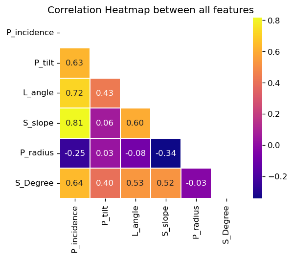

```python
plt.figure(dpi = 120, figsize = (5,4))
mask = np.triu(np.ones_like(df_combined.corr()))
sns.heatmap(df_combined.corr(), mask = mask, fmt = ".2f", annot = True, lw = 1, cmap = 'plasma')
plt.yticks(rotation = 0)
plt.xticks(rotation = 90)
plt.title('Correlation Heatmap between all features')
plt.show()
```

B. Share insights on correlation. [2 Marks]

```
A. Features having stronger correlation with correlation value.
B. Features having weaker correlation with correlation value.
```

#### A. Features having stronger correlation with correlation value :

Correlation between P_incidence and S_slope is 0.81

Correlation between P_incidence and L_angle is 0.72

Correlation between P_incidence and S_Degree is 0.64

Correlation between P_incidence and P_tilt is 0.63

Correlation between L_angle and S_slope is 0.60

Correlation between S_Degree and L_angle is 0.53

Correlation between S_Degree and S_slope is 0.52

#### B. Features having Moderate correlation with correlation value :

Correlation between P_tilt and L_angle is 0.43

Correlation between P_tilt and S_Degree is 0.40

Correlation between S_slope and P_radius is -0.34

#### C. Features having Weaker correlation with correlation value :

Correlation between P_incidence and P_radius is -0.25

Correlation between P_tilt and S_slope is 0.06

Correlation between P_tilt and P_radius is 0.03

Correlation between L_angle and P_radius is -0.08

Correlation between P_radius and S_Degree is -0.03

Coefficient of Correlation

Value of r Strength of relationship

-1.0 to -0.5 or 1.0 to 0.5 => Strong

-0.5 to -0.3 or 0.3 to 0.5 => Moderate

-0.3 to -0.1 or 0.1 to 0.3 => Weak

-0.1 to 0.1 => None or very weak

C. Visualize a pairplot with 3 classes distinguished by colors and share insights. [2 Marks]

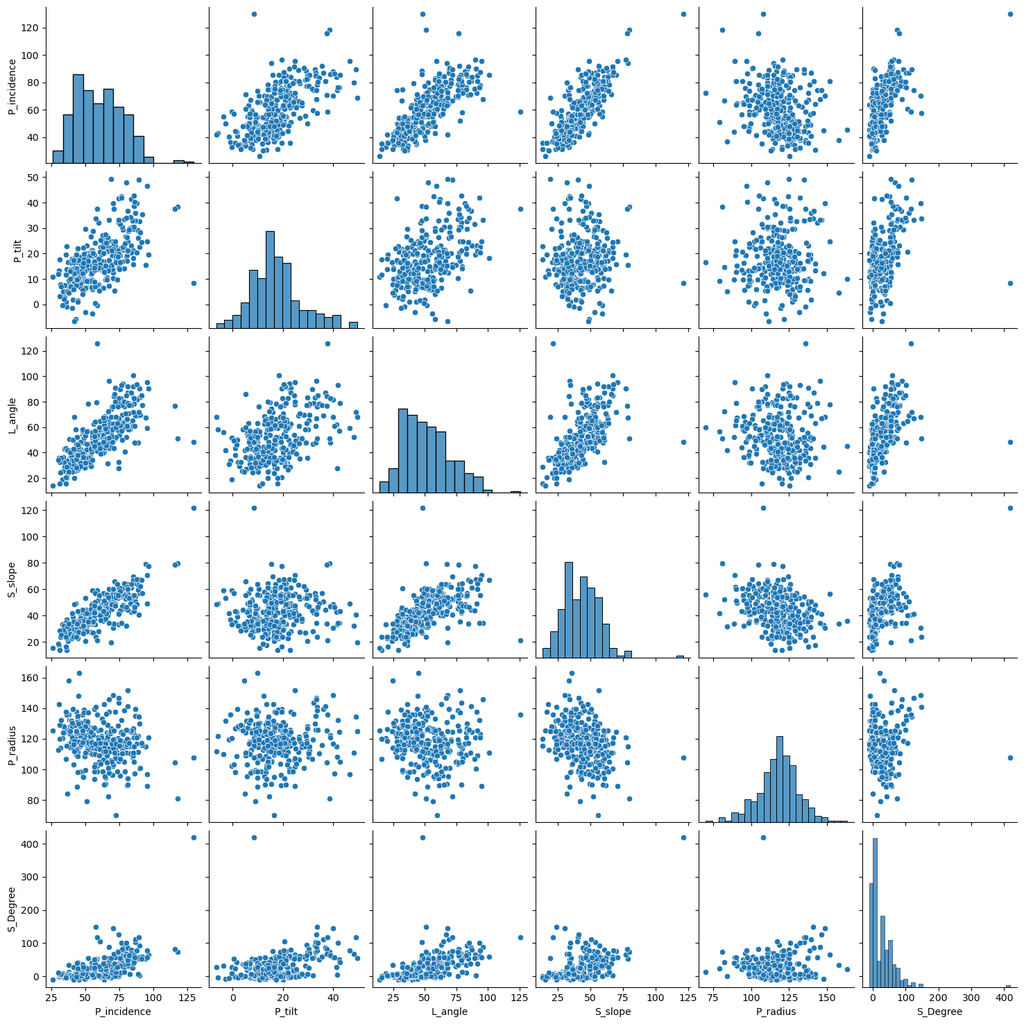

```python
# Pair Plot of independent Variables

sns.pairplot(df_combined)
plt.show()
```

P_incidence has postive realtionship with all variables except P_radius.

P_tilt has Higher Relationship with P_incidence and L_angle. There is no Relationship with s_slope and p_radius.

L_angle has postive Relationship with P_tilt, S_slope and S_degree. It has no Relationship with P_radius

S_slope has positive Relationship with L_angle and S_degree

P_radius has no Relationship with S_degree, P_tilt, L_angle.

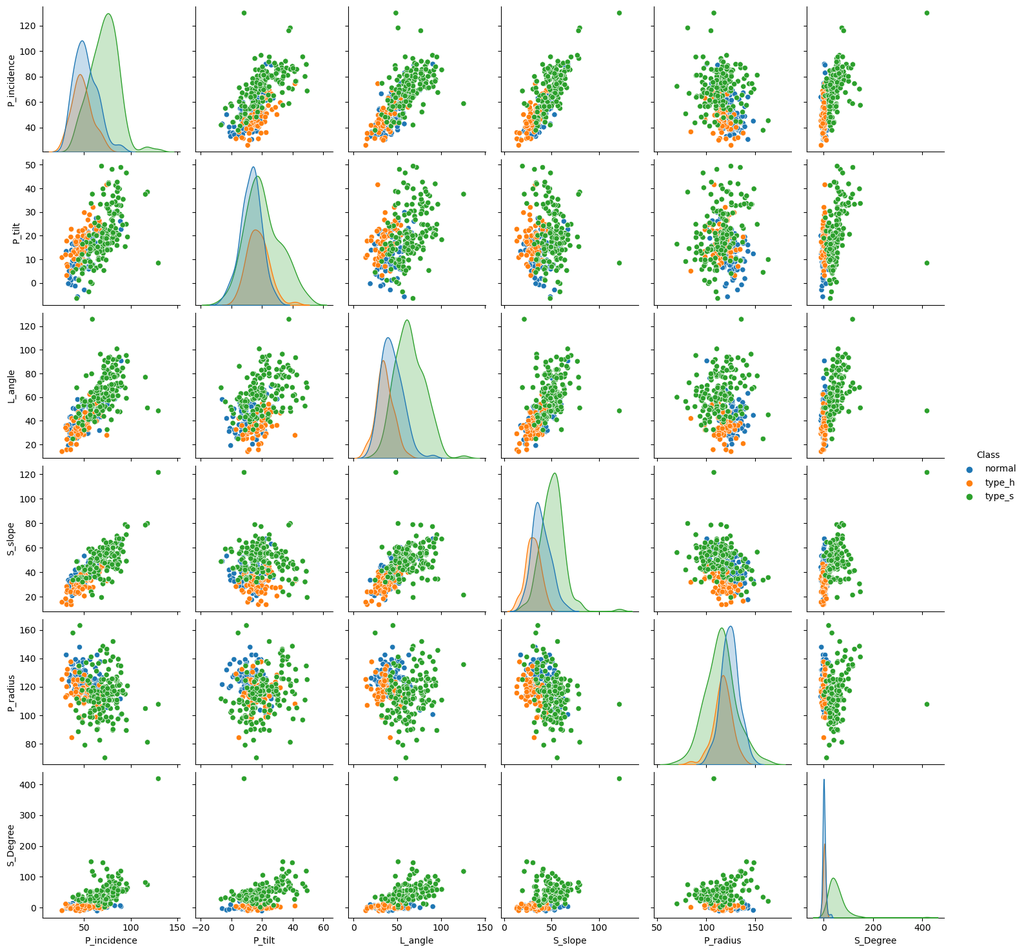

```python
sns.pairplot(df_combined, hue = 'Class')
plt.show()
```

P_incidence has postive realtionship with all variables except P_radius.

P_tilt has Higher Relationship with P_incidence and L_angle. There is no Relationship with s_slope and p_radius.

L_angle has postive Relationship with P_tilt, S_slope and S_degree. It has no Relationship with P_radius

S_slope has positive Relationship with L_angle and S_degree

P_radius has no Relationship with S_degree, P_tilt, L_angle.

D. Visualize a jointplot for ‘P_incidence’ and ‘S_slope’ and share insights. [2 Marks]

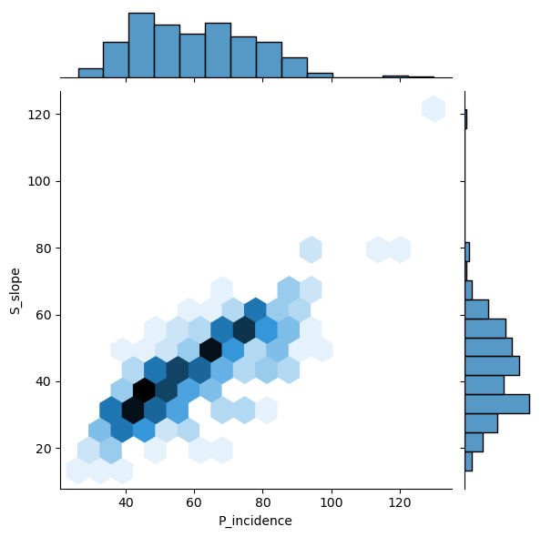

```python
sns.jointplot(x = "P_incidence", y = "S_slope", kind = "hex", data = df_combined, dropna = True)
plt.show()
```

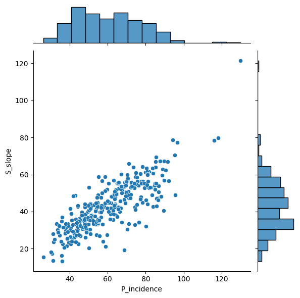

```python
sns.jointplot(x = "P_incidence", y = "S_slope", kind = "scatter", data = df_combined, dropna = True)
plt.show()
```

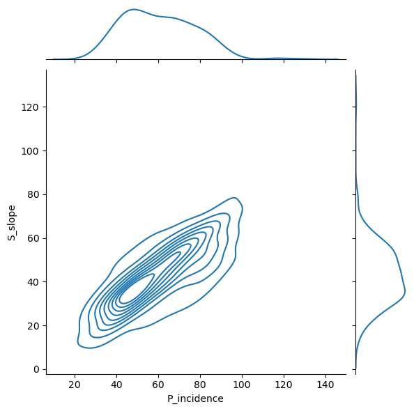

```python
sns.jointplot(x = "P_incidence", y = "S_slope", kind = "kde", data = df_combined, dropna = True)
plt.show()
```

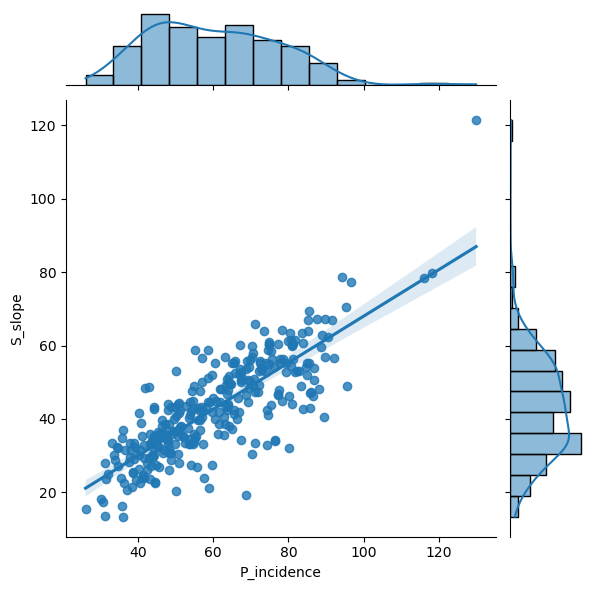

```python
sns.jointplot(x = "P_incidence", y = "S_slope", kind = "reg", data = df_combined, dropna = True)
plt.show()
```

E. Visualize a boxplot to check distribution of the features and share insights. [2 Marks]

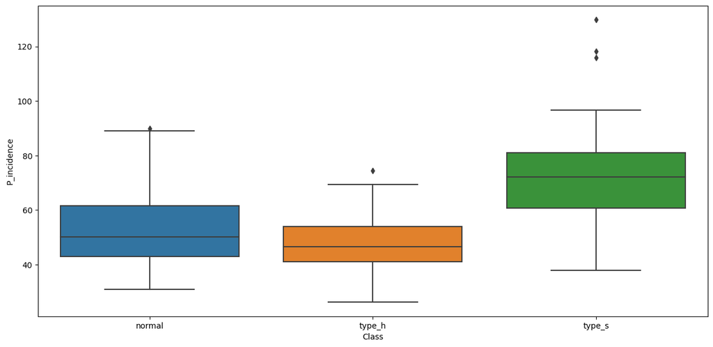

```python
plt.figure(figsize = (15,7))
sns.boxplot(x = 'Class', y = 'P_incidence', data = df_combined)
plt.show()
```

P_Incidence Value is larger for type_s Class. We can see some extreme values as well

normal Value is slightly higher than type_h

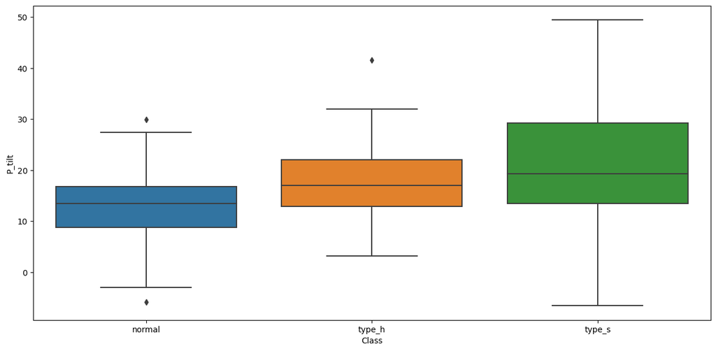

```python
plt.figure(figsize = (15,7))
sns.boxplot(x = 'Class', y = 'P_tilt', data = df_combined)
plt.show()
```

Mean of type_s is slightly higher than rest two

Few cases normal and type_h also has huge values

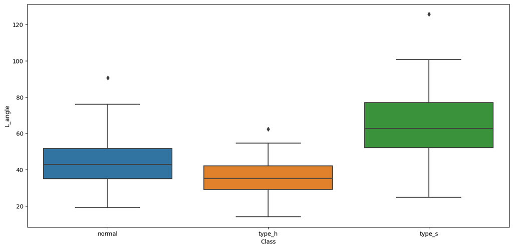

```python
plt.figure(figsize = (15,7))
sns.boxplot(x = 'Class', y = 'L_angle', data = df_combined)
plt.show()
```

L_Angle has higher value for type_s Class

We can see normal has higher values compared to type_h

Each class contains one outlier

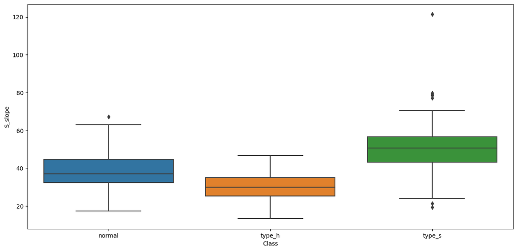

```python
plt.figure(figsize = (15,7))
sns.boxplot(x = 'Class', y = 'S_slope', data = df_combined)
plt.show()
```

S_slope has huge values for type_s class

normal has high S_slope compared to type_h

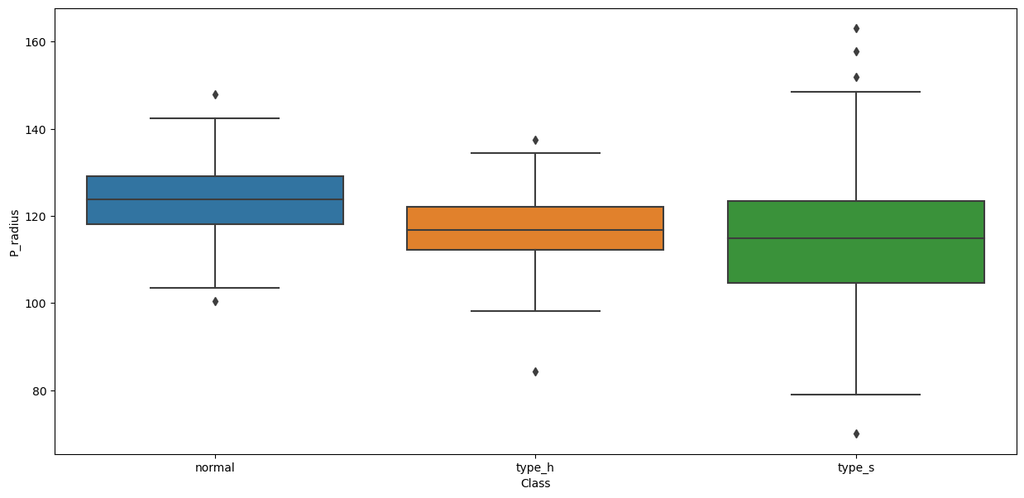

```python
plt.figure(figsize = (15,7))
sns.boxplot(x = 'Class', y = 'P_radius', data = df_combined)
plt.show()
```

We can see P_radius value is more for normal

There is some extreme values for type_s

All classes has higher and lower Value

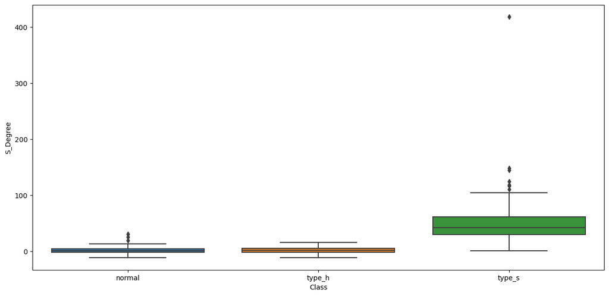

```python
plt.figure(figsize = (15,7))
sns.boxplot(x = 'Class', y = 'S_Degree', data = df_combined)
plt.show()
```

S_Degree has extreme values for type_s

Few normal also has huge values for S_Degree

1. Model Building: [6 Marks]

A. Split data into X and Y. [1 Marks]

```python
df_combined['Class'] = df_combined.Class.astype('category')
```

```python
df_combined.describe().transpose()
```

|  | count | mean | std | min | 25% | 50% | 75% | max |
| --- | --- | --- | --- | --- | --- | --- | --- | --- |
| P_incidence | 310.0 | 60.496653 | 17.236520 | 26.147921 | 46.430294 | 58.691038 | 72.877696 | 129.834041 |
| P_tilt | 310.0 | 17.542822 | 10.008330 | -6.554948 | 10.667069 | 16.357689 | 22.120395 | 49.431864 |
| L_angle | 310.0 | 51.930930 | 18.554064 | 14.000000 | 37.000000 | 49.562398 | 63.000000 | 125.742385 |
| S_slope | 310.0 | 42.953831 | 13.423102 | 13.366931 | 33.347122 | 42.404912 | 52.695888 | 121.429566 |
| P_radius | 310.0 | 117.920655 | 13.317377 | 70.082575 | 110.709196 | 118.268178 | 125.467674 | 163.071041 |
| S_Degree | 310.0 | 26.296694 | 37.559027 | -11.058179 | 1.603727 | 11.767934 | 41.287352 | 418.543082 |

```python
df_combined.groupby(['Class']).count()
```

| Class | P_incidence | P_tilt | L_angle | S_slope | P_radius | S_Degree |
| --- | --- | --- | --- | --- | --- | --- |
| normal | 100 | 100 | 100 | 100 | 100 | 100 |
| type_h | 60 | 60 | 60 | 60 | 60 | 60 |
| type_s | 150 | 150 | 150 | 150 | 150 | 150 |

```python
df_combined.shape
```

```
(310, 7)
```

```python
# Create a separate dataframe consisting only of the features i.e independent attributes

X = df_combined.drop(columns='Class')
y = df_combined["Class"]

X.head()
```

|  | P_incidence | P_tilt | L_angle | S_slope | P_radius | S_Degree |
| --- | --- | --- | --- | --- | --- | --- |
| 0 | 38.505273 | 16.964297 | 35.112814 | 21.540976 | 127.632875 | 7.986683 |
| 1 | 54.920858 | 18.968430 | 51.601455 | 35.952428 | 125.846646 | 2.001642 |
| 2 | 44.362490 | 8.945435 | 46.902096 | 35.417055 | 129.220682 | 4.994195 |
| 3 | 48.318931 | 17.452121 | 48.000000 | 30.866809 | 128.980308 | -0.910941 |
| 4 | 45.701789 | 10.659859 | 42.577846 | 35.041929 | 130.178314 | -3.388910 |

```python
# convert the features into z scores as we do not know what units / scales were used and store them in new dataframe
# It is always adviced to scale numeric attributes in models that calculate distances.

X_Scaled = X.apply(zscore)  # convert all attributes to Z scale
X_Scaled.describe().T
```

|  | count | mean | std | min | 25% | 50% | 75% | max |
| --- | --- | --- | --- | --- | --- | --- | --- | --- |
| P_incidence | 310.0 | -1.375244e-16 | 1.001617 | -1.996010 | -0.817398 | -0.104925 | 0.719464 | 4.029206 |
| P_tilt | 310.0 | 2.292073e-16 | 1.001617 | -2.411664 | -0.688114 | -0.118606 | 0.458116 | 3.191402 |
| L_angle | 310.0 | 1.833659e-16 | 1.001617 | -2.047652 | -0.806027 | -0.127862 | 0.597549 | 3.984615 |
| S_slope | 310.0 | -1.833659e-16 | 1.001617 | -2.207741 | -0.716842 | -0.040960 | 0.726941 | 5.855771 |
| P_radius | 310.0 | -6.876220e-16 | 1.001617 | -3.597963 | -0.542383 | 0.026138 | 0.567621 | 3.395818 |
| S_Degree | 310.0 | -4.584147e-17 | 1.001617 | -0.996172 | -0.658507 | -0.387450 | 0.399768 | 10.460350 |

B. Split data into train and test with 80:20 proportion. [1 Marks]

```python
# Split X and y into training and test set in 80:20 ratio

X_train, X_test, y_train, y_test = train_test_split(X, y, test_size = 0.20, random_state = 1)
```

```python
print("{0:0.2f}% data is in training set".format((len(X_train) / len(df_combined.index)) * 100))
print("{0:0.2f}% data is in test set".format((len(X_test) / len(df_combined.index)) * 100))
```

```
80.00% data is in training set
20.00% data is in test set
```

C. Train a Supervised Learning Classification base model using KNN classifier. [2 Marks]

```python
KNN = KNeighborsClassifier(n_neighbors= 5, metric = 'euclidean')
KNN.fit(X_train, y_train)
```

```
KNeighborsClassifier(metric='euclidean')
```

```python
# For every test data point, predict it's label based on 5 nearest neighbours in this model. The majority class will
# be assigned to the test data point

predicted_labels = KNN.predict(X_test)

print('Accuracy on Training data: ', KNN.score(X_train, y_train))
print('Accuracy on Test data: ', KNN.score(X_test, y_test))
```

```
Accuracy on Training data:  0.8911290322580645
Accuracy on Test data:  0.8387096774193549
```

D. Print all the possible performance metrics for both train and test data. [2 Marks]

```python
confusion_matrix(y_test, predicted_labels)
```

```
array([[16,  1,  1],
       [ 4,  7,  0],
       [ 4,  0, 29]], dtype=int64)
```

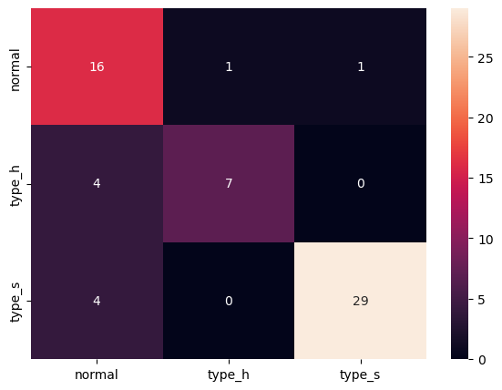

```python
# calculate accuracy measures and confusion matrix

cm = confusion_matrix(y_test, predicted_labels)
df_cm = pd.DataFrame(cm, index = [i for i in ["normal", "type_h", "type_s"]], columns = [i for i in ["normal", "type_h", "type_s"]])
plt.figure(figsize = (7, 5))
sns.heatmap(df_cm, annot = True, fmt = 'g')
plt.show()
```

```python
classification_report(y_test, predicted_labels)
```

[output not shown]

1. Performance Improvement: [4 Marks]

A. Experiment with various parameters to improve performance of the base model. [2 Marks]

(Optional: Experiment with various Hyperparameters - Research required)

```python
LR_model=LogisticRegression()
KNN_model=KNeighborsClassifier(n_neighbors=13)
GN_model=GaussianNB()
svc_model_linear = SVC(kernel='linear', C=1, gamma=.6)
svc_model_rbf = SVC(kernel='rbf', degree=2, C=.009)
svc_model_poly  = SVC(kernel='poly', degree=2, gamma=0.1, C=.01)
```

```python
seed = 7

# prepare models
models = []
models.append(('LR', LR_model))
models.append(('KNN', KNN_model))
models.append(('NB', GN_model))
models.append(('SVM-linear', svc_model_linear))
models.append(('SVM-poly', svc_model_poly))
models.append(('SVM-rbf', svc_model_rbf))

# evaluate each model in turn
results = []
names = []
scoring = 'accuracy'
for name, model in models:
    kfold = model_selection.KFold(n_splits = 10, random_state = seed, shuffle = True)
    cv_results = model_selection.cross_val_score(model, X, y, cv = kfold, scoring = scoring)
    results.append(cv_results)
    names.append(name)
    msg = "%s: %f (%f)" % (name, cv_results.mean(), cv_results.std())
    print(msg)
```

[output not shown]

[output cut: 25 more lines]

[output not shown]

```
LR: 0.864516 (0.049556)
KNN: 0.829032 (0.054074)
NB: 0.825806 (0.035921)
SVM-linear: 0.848387 (0.066188)
SVM-poly: 0.819355 (0.050389)
SVM-rbf: 0.483871 (0.070674)
```

B. Clearly showcase improvement in performance achieved. [1 Marks]

```
For Example:
    A. Accuracy: +15% improvement
    B. Precision: +10% improvement.
```

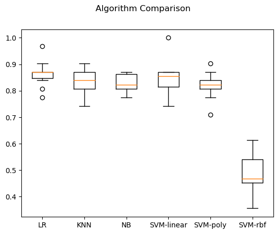

```python
# boxplot algorithm comparison
fig = plt.figure()
fig.suptitle('Algorithm Comparison')

ax = fig.add_subplot(111)
plt.boxplot(results)
ax.set_xticklabels(names)
plt.show()
```

C. Clearly state which parameters contributed most to improve model performance. [1 Marks]

[output not shown]

### Part B - 30 Marks

1. Data Understanding and Preparation: [5 Marks]

A. Read both the Datasets ‘Data1’ and ‘Data 2’ as DataFrame and store them into two separate variables. [1 Marks]

```python
df_data1 = pd.read_csv('Part2 - Data1.csv')
```

```python
df_data2 = pd.read_csv('Part2 - Data2.csv')
```

```python
df_data1.head()
```

|  | ID | Age | CustomerSince | HighestSpend | ZipCode | HiddenScore | MonthlyAverageSpend | Level |
| --- | --- | --- | --- | --- | --- | --- | --- | --- |
| 0 | 1 | 25 | 1 | 49 | 91107 | 4 | 1.6 | 1 |
| 1 | 2 | 45 | 19 | 34 | 90089 | 3 | 1.5 | 1 |
| 2 | 3 | 39 | 15 | 11 | 94720 | 1 | 1.0 | 1 |
| 3 | 4 | 35 | 9 | 100 | 94112 | 1 | 2.7 | 2 |
| 4 | 5 | 35 | 8 | 45 | 91330 | 4 | 1.0 | 2 |

```python
df_data2.head()
```

|  | ID | Mortgage | Security | FixedDepositAccount | InternetBanking | CreditCard | LoanOnCard |
| --- | --- | --- | --- | --- | --- | --- | --- |
| 0 | 1 | 0 | 1 | 0 | 0 | 0 | NaN |
| 1 | 2 | 0 | 1 | 0 | 0 | 0 | NaN |
| 2 | 3 | 0 | 0 | 0 | 0 | 0 | NaN |
| 3 | 4 | 0 | 0 | 0 | 0 | 0 | NaN |
| 4 | 5 | 0 | 0 | 0 | 0 | 1 | NaN |

B. Print shape and Column Names and DataTypes of both the Dataframes. [1 Marks]

```python
df_data1.shape
```

```
(5000, 8)
```

```python
df_data2.shape
```

```
(5000, 7)
```

```python
df_data1.columns
```

```
Index(['ID', 'Age', 'CustomerSince', 'HighestSpend', 'ZipCode', 'HiddenScore',
       'MonthlyAverageSpend', 'Level'],
      dtype='object')
```

```python
df_data2.columns
```

```
Index(['ID', 'Mortgage', 'Security', 'FixedDepositAccount', 'InternetBanking',
       'CreditCard', 'LoanOnCard'],
      dtype='object')
```

C. Merge both the Dataframes on ‘ID’ feature to form a single DataFrame [2 Marks]

```python
df_merged = df_data1.merge(df_data2, left_on = 'ID', right_on = 'ID')
df_merged.head()
```

|  | ID | Age | CustomerSince | HighestSpend | ZipCode | HiddenScore | MonthlyAverageSpend | Level | Mortgage | Security | FixedDepositAccount | InternetBanking | CreditCard | LoanOnCard |
| --- | --- | --- | --- | --- | --- | --- | --- | --- | --- | --- | --- | --- | --- | --- |
| 0 | 1 | 25 | 1 | 49 | 91107 | 4 | 1.6 | 1 | 0 | 1 | 0 | 0 | 0 | NaN |
| 1 | 2 | 45 | 19 | 34 | 90089 | 3 | 1.5 | 1 | 0 | 1 | 0 | 0 | 0 | NaN |
| 2 | 3 | 39 | 15 | 11 | 94720 | 1 | 1.0 | 1 | 0 | 0 | 0 | 0 | 0 | NaN |
| 3 | 4 | 35 | 9 | 100 | 94112 | 1 | 2.7 | 2 | 0 | 0 | 0 | 0 | 0 | NaN |
| 4 | 5 | 35 | 8 | 45 | 91330 | 4 | 1.0 | 2 | 0 | 0 | 0 | 0 | 1 | NaN |

```python
df_merged.shape
```

```
(5000, 14)
```

```python
df_merged.columns
```

```
Index(['ID', 'Age', 'CustomerSince', 'HighestSpend', 'ZipCode', 'HiddenScore',
       'MonthlyAverageSpend', 'Level', 'Mortgage', 'Security',
       'FixedDepositAccount', 'InternetBanking', 'CreditCard', 'LoanOnCard'],
      dtype='object')
```

```python
df_merged.info()
```

```
<class 'pandas.core.frame.DataFrame'>
Int64Index: 5000 entries, 0 to 4999
Data columns (total 14 columns):
 #   Column               Non-Null Count  Dtype
---  ------               --------------  -----
 0   ID                   5000 non-null   int64
 1   Age                  5000 non-null   int64
 2   CustomerSince        5000 non-null   int64
 3   HighestSpend         5000 non-null   int64
 4   ZipCode              5000 non-null   int64
 5   HiddenScore          5000 non-null   int64
 6   MonthlyAverageSpend  5000 non-null   float64
 7   Level                5000 non-null   int64
 8   Mortgage             5000 non-null   int64
 9   Security             5000 non-null   int64
 10  FixedDepositAccount  5000 non-null   int64
 11  InternetBanking      5000 non-null   int64
 12  CreditCard           5000 non-null   int64
 13  LoanOnCard           4980 non-null   float64
dtypes: float64(2), int64(12)
memory usage: 585.9 KB
```

```python
df_merged.describe()
```

|  | ID | Age | CustomerSince | HighestSpend | ZipCode | HiddenScore | MonthlyAverageSpend | Level | Mortgage | Security | FixedDepositAccount | InternetBanking | CreditCard | LoanOnCard |
| --- | --- | --- | --- | --- | --- | --- | --- | --- | --- | --- | --- | --- | --- | --- |
| count | 5000.000000 | 5000.000000 | 5000.000000 | 5000.000000 | 5000.000000 | 5000.000000 | 5000.000000 | 5000.000000 | 5000.000000 | 5000.000000 | 5000.00000 | 5000.000000 | 5000.000000 | 4980.000000 |
| mean | 2500.500000 | 45.338400 | 20.104600 | 73.774200 | 93152.503000 | 2.396400 | 1.937938 | 1.881000 | 56.498800 | 0.104400 | 0.06040 | 0.596800 | 0.294000 | 0.096386 |
| std | 1443.520003 | 11.463166 | 11.467954 | 46.033729 | 2121.852197 | 1.147663 | 1.747659 | 0.839869 | 101.713802 | 0.305809 | 0.23825 | 0.490589 | 0.455637 | 0.295149 |
| min | 1.000000 | 23.000000 | -3.000000 | 8.000000 | 9307.000000 | 1.000000 | 0.000000 | 1.000000 | 0.000000 | 0.000000 | 0.00000 | 0.000000 | 0.000000 | 0.000000 |
| 25% | 1250.750000 | 35.000000 | 10.000000 | 39.000000 | 91911.000000 | 1.000000 | 0.700000 | 1.000000 | 0.000000 | 0.000000 | 0.00000 | 0.000000 | 0.000000 | 0.000000 |
| 50% | 2500.500000 | 45.000000 | 20.000000 | 64.000000 | 93437.000000 | 2.000000 | 1.500000 | 2.000000 | 0.000000 | 0.000000 | 0.00000 | 1.000000 | 0.000000 | 0.000000 |
| 75% | 3750.250000 | 55.000000 | 30.000000 | 98.000000 | 94608.000000 | 3.000000 | 2.500000 | 3.000000 | 101.000000 | 0.000000 | 0.00000 | 1.000000 | 1.000000 | 0.000000 |
| max | 5000.000000 | 67.000000 | 43.000000 | 224.000000 | 96651.000000 | 4.000000 | 10.000000 | 3.000000 | 635.000000 | 1.000000 | 1.00000 | 1.000000 | 1.000000 | 1.000000 |

```python
df_merged.dtypes
```

```
ID                       int64
Age                      int64
CustomerSince            int64
HighestSpend             int64
ZipCode                  int64
HiddenScore              int64
MonthlyAverageSpend    float64
Level                    int64
Mortgage                 int64
Security                 int64
FixedDepositAccount      int64
InternetBanking          int64
CreditCard               int64
LoanOnCard             float64
dtype: object
```

D. Change Datatype of below features to ‘Object’ [1 Marks]

‘CreditCard’, ‘InternetBanking’, ‘FixedDepositAccount’, ‘Security’, ‘Level’, ‘HiddenScore’.

[Reason behind performing this operation:- Values in these features are binary i.e. 1/0. But DataType is ‘int’/’float’ which is not expected.]

```python
df_merged.dtypes
```

```
ID                       int64
Age                      int64
CustomerSince            int64
HighestSpend             int64
ZipCode                  int64
HiddenScore              int64
MonthlyAverageSpend    float64
Level                    int64
Mortgage                 int64
Security                 int64
FixedDepositAccount      int64
InternetBanking          int64
CreditCard               int64
LoanOnCard             float64
dtype: object
```

```python
change_col_name = ['CreditCard', 'InternetBanking', 'FixedDepositAccount', 'Security', 'Level', 'HiddenScore']

for i in change_col_name:
    df_merged[i] = df_merged[i].astype('object')
```

```python
df_merged.dtypes
```

```
ID                       int64
Age                      int64
CustomerSince            int64
HighestSpend             int64
ZipCode                  int64
HiddenScore             object
MonthlyAverageSpend    float64
Level                   object
Mortgage                 int64
Security                object
FixedDepositAccount     object
InternetBanking         object
CreditCard              object
LoanOnCard             float64
dtype: object
```

1. Data Exploration and Analysis: [5 Marks]

A. Visualize distribution of Target variable ‘LoanOnCard’ and clearly share insights. [2 Marks]

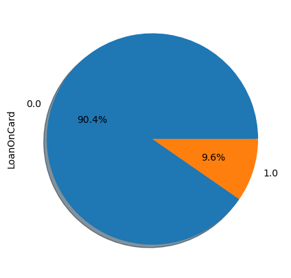

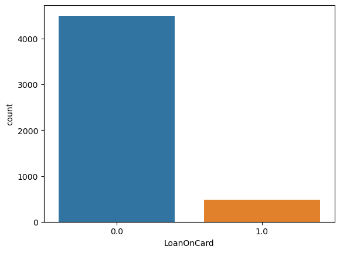

```python
axes = plt.figure(figsize = (7, 5))
df_merged['LoanOnCard'].value_counts().plot.pie(autopct = '%1.1f%%', shadow = True)
plt.show()

sns.countplot(x ='LoanOnCard', data = df_merged)
plt.show()
```

We can see 90.4% of people does not have loan on credit card and remaining 9.6% loan on credit card

B. Check the percentage of missing values and impute if required. [1 Marks]

```python
percent_missing = df_merged.isnull().sum() * 100 / len(df_merged)
percent_missing
```

```
ID                     0.0
Age                    0.0
CustomerSince          0.0
HighestSpend           0.0
ZipCode                0.0
HiddenScore            0.0
MonthlyAverageSpend    0.0
Level                  0.0
Mortgage               0.0
Security               0.0
FixedDepositAccount    0.0
InternetBanking        0.0
CreditCard             0.0
LoanOnCard             0.4
dtype: float64
```

```python
df_merged.dropna(axis = 0, inplace = True)
```

```python
percent_missing = df_merged.isnull().sum() * 100 / len(df_merged)
percent_missing
```

```
ID                     0.0
Age                    0.0
CustomerSince          0.0
HighestSpend           0.0
ZipCode                0.0
HiddenScore            0.0
MonthlyAverageSpend    0.0
Level                  0.0
Mortgage               0.0
Security               0.0
FixedDepositAccount    0.0
InternetBanking        0.0
CreditCard             0.0
LoanOnCard             0.0
dtype: float64
```

As we had and very less missing value so we will drop the missing records from the dataframe.

C. Check for unexpected values in each categorical variable and impute with best suitable value. [2 Marks]

[Unexpected values means if all values in a feature are 0/1 then ‘?’, ‘a’, 1.5 are unexpected values which needs treatment ]

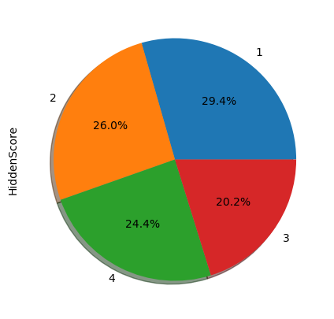

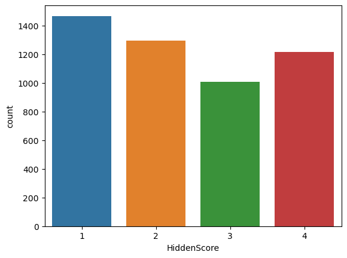

```python
axes = plt.figure(figsize = (7, 5))
df_merged['HiddenScore'].value_counts().plot.pie(autopct = '%1.1f%%', shadow = True)
plt.show()

sns.countplot(x ='HiddenScore', data = df_merged)
plt.show()
```

We can see nearly equal distribution of each category

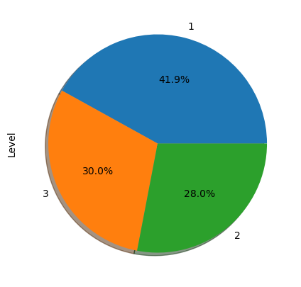

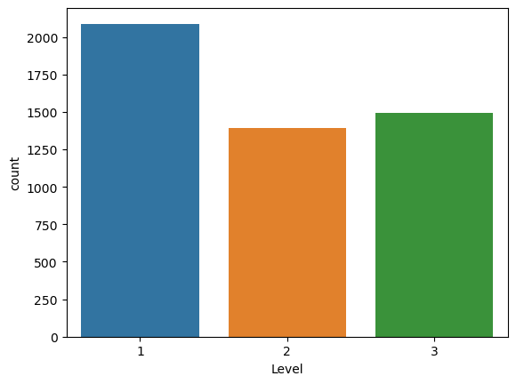

```python
axes = plt.figure(figsize = (7, 5))
df_merged['Level'].value_counts().plot.pie(autopct = '%1.1f%%', shadow = True)
plt.show()

sns.countplot(x ='Level', data = df_merged)
plt.show()
```

Level 1 customers are more compared to others

Level 2 and 3 has nearly equal distribution

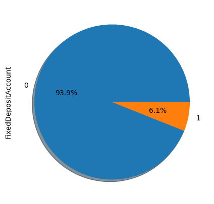

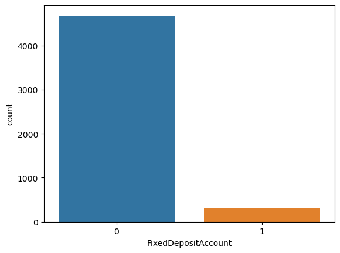

```python
axes = plt.figure(figsize = (7, 5))
df_merged['FixedDepositAccount'].value_counts().plot.pie(autopct = '%1.1f%%', shadow = True)
plt.show()

sns.countplot(x ='FixedDepositAccount', data = df_merged)
plt.show()
```

We can see 93.9% of customers does not have fixed deposit account and 6.1% of customers have fixed deposit account

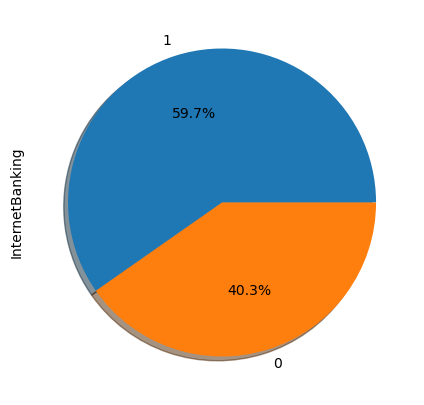

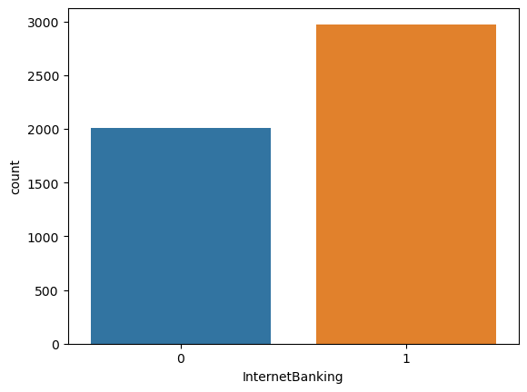

```python
axes = plt.figure(figsize = (7, 5))
df_merged['InternetBanking'].value_counts().plot.pie(autopct = '%1.1f%%', shadow = True)
plt.show()

sns.countplot(x ='InternetBanking', data = df_merged)
plt.show()
```

We can see 59.7% of customers uses internet banking and 40.3% of customers does not uses internet banking

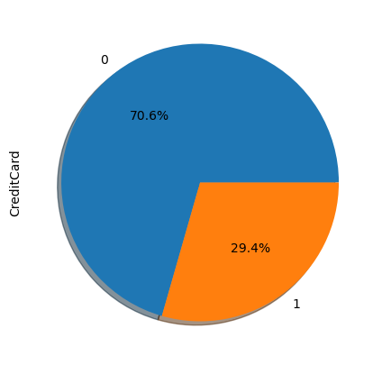

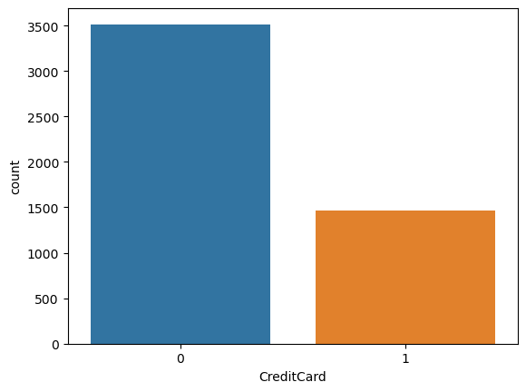

```python
axes = plt.figure(figsize = (7, 5))
df_merged['CreditCard'].value_counts().plot.pie(autopct = '%1.1f%%', shadow = True)
plt.show()

sns.countplot(x ='CreditCard', data = df_merged)
plt.show()
```

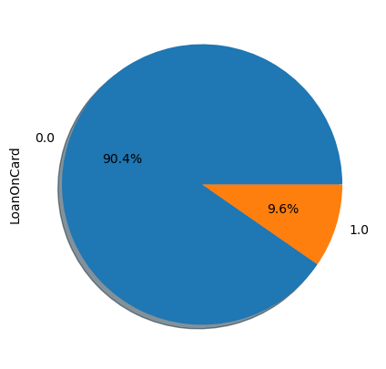

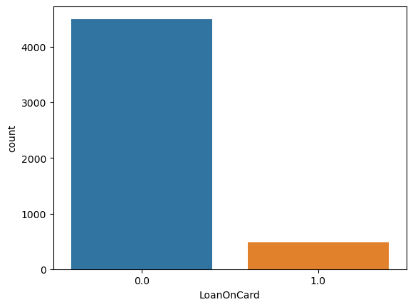

```python
axes = plt.figure(figsize = (7, 5))
df_merged['LoanOnCard'].value_counts().plot.pie(autopct = '%1.1f%%', shadow = True)
plt.show()

sns.countplot(x ='LoanOnCard', data = df_merged)
plt.show()
```

We can see 90.4% of people does not have loan on credit card and remaining 9.6% loan on credit card

1. Data Preparation and model building: [10 Marks]

A. Split data into X and Y. [1 Marks]

[Recommended to drop ID & ZipCode. LoanOnCard is target Variable]

```python
df_merged.drop('ID', axis = 1, inplace = True)
df_merged.drop('ZipCode', axis = 1, inplace = True)
```

```python
df_merged['LoanOnCard'] = df_merged.LoanOnCard.astype('category')
```

```python
df_merged.describe().transpose()
```

|  | count | mean | std | min | 25% | 50% | 75% | max |
| --- | --- | --- | --- | --- | --- | --- | --- | --- |
| Age | 4980.0 | 45.352610 | 11.464212 | 23.0 | 35.0 | 45.0 | 55.000 | 67.0 |
| CustomerSince | 4980.0 | 20.117671 | 11.468716 | -3.0 | 10.0 | 20.0 | 30.000 | 43.0 |
| HighestSpend | 4980.0 | 73.852410 | 46.070090 | 8.0 | 39.0 | 64.0 | 98.000 | 224.0 |
| MonthlyAverageSpend | 4980.0 | 1.939536 | 1.750006 | 0.0 | 0.7 | 1.5 | 2.525 | 10.0 |
| Mortgage | 4980.0 | 56.589759 | 101.836758 | 0.0 | 0.0 | 0.0 | 101.000 | 635.0 |

```python
df_merged.groupby(['LoanOnCard']).count()
```

| LoanOnCard | Age | CustomerSince | HighestSpend | HiddenScore | MonthlyAverageSpend | Level | Mortgage | Security | FixedDepositAccount | InternetBanking | CreditCard |
| --- | --- | --- | --- | --- | --- | --- | --- | --- | --- | --- | --- |
| 0.0 | 4500 | 4500 | 4500 | 4500 | 4500 | 4500 | 4500 | 4500 | 4500 | 4500 | 4500 |
| 1.0 | 480 | 480 | 480 | 480 | 480 | 480 | 480 | 480 | 480 | 480 | 480 |

```python
df_merged.shape
```

```
(4980, 12)
```

```python
X = df_merged.drop(columns = 'LoanOnCard')
y = df_merged["LoanOnCard"]

X.head()
```

|  | Age | CustomerSince | HighestSpend | HiddenScore | MonthlyAverageSpend | Level | Mortgage | Security | FixedDepositAccount | InternetBanking | CreditCard |
| --- | --- | --- | --- | --- | --- | --- | --- | --- | --- | --- | --- |
| 9 | 34 | 9 | 180 | 1 | 8.9 | 3 | 0 | 0 | 0 | 0 | 0 |
| 10 | 65 | 39 | 105 | 4 | 2.4 | 3 | 0 | 0 | 0 | 0 | 0 |
| 11 | 29 | 5 | 45 | 3 | 0.1 | 2 | 0 | 0 | 0 | 1 | 0 |
| 12 | 48 | 23 | 114 | 2 | 3.8 | 3 | 0 | 1 | 0 | 0 | 0 |
| 13 | 59 | 32 | 40 | 4 | 2.5 | 2 | 0 | 0 | 0 | 1 | 0 |

B. Split data into train and test. Keep 25% data reserved for testing. [1 Marks]

```python
# Split X and y into testing set in 25%

X_train, X_test, y_train, y_test = train_test_split(X, y, test_size = 0.25, random_state = 1)
```

```python
print("{0:0.2f}% data is in training set".format((len(X_train) / len(df_merged.index)) * 100))
print("{0:0.2f}% data is in test set".format((len(X_test) / len(df_merged.index)) * 100))
```

```
75.00% data is in training set
25.00% data is in test set
```

```python
print("Original LoanOnCard True Values    : {0} ({1:0.2f}%)".format(len(df_merged.loc[df_merged['LoanOnCard'] == 1]), (len(df_merged.loc[df_merged['LoanOnCard'] == 1])/len(df_merged.index)) * 100))
print("Original LoanOnCard False Values   : {0} ({1:0.2f}%)".format(len(df_merged.loc[df_merged['LoanOnCard'] == 0]), (len(df_merged.loc[df_merged['LoanOnCard'] == 0])/len(df_merged.index)) * 100))
print("")
print("Training LoanOnCard True Values    : {0} ({1:0.2f}%)".format(len(y_train[y_train[:] == 1]), (len(y_train[y_train[:] == 1])/len(y_train)) * 100))
print("Training LoanOnCard False Values   : {0} ({1:0.2f}%)".format(len(y_train[y_train[:] == 0]), (len(y_train[y_train[:] == 0])/len(y_train)) * 100))
print("")
print("Test LoanOnCard True Values        : {0} ({1:0.2f}%)".format(len(y_test[y_test[:] == 1]), (len(y_test[y_test[:] == 1])/len(y_test)) * 100))
print("Test LoanOnCard False Values       : {0} ({1:0.2f}%)".format(len(y_test[y_test[:] == 0]), (len(y_test[y_test[:] == 0])/len(y_test)) * 100))
print("")
```

```
Original LoanOnCard True Values    : 480 (9.64%)
Original LoanOnCard False Values   : 4500 (90.36%)

Training LoanOnCard True Values    : 353 (9.45%)
Training LoanOnCard False Values   : 3382 (90.55%)

Test LoanOnCard True Values        : 127 (10.20%)
Test LoanOnCard False Values       : 1118 (89.80%)
```

C. Train a Supervised Learning Classification base model - Logistic Regression. [2 Marks]

```python
logisticRegression = LogisticRegression()
logisticRegression.fit(X_train, y_train)
```

[output not shown]

```
LogisticRegression()
```

```python
predicted_labels = logisticRegression.predict(X_test)

print('Accuracy on Training data: ', logisticRegression.score(X_train, y_train))
print('Accuracy on Test data: ', logisticRegression.score(X_test, y_test))
```

```
Accuracy on Training data:  0.9493975903614458
Accuracy on Test data:  0.9437751004016064
```

D. Print evaluation metrics for the model and clearly share insights. [1 Marks]

```python
confusion_matrix(y_test, predicted_labels)
```

```
array([[1102,   16],
       [  54,   73]], dtype=int64)
```

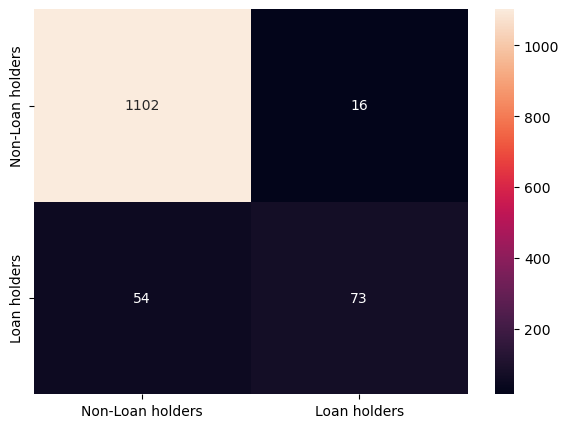

```python
# calculate accuracy measures and confusion matrix

cm = confusion_matrix(y_test, predicted_labels)
df_cm = pd.DataFrame(cm, index = [i for i in ["Non-Loan holders","Loan holders"]], columns = [i for i in ["Non-Loan holders","Loan holders"]])
plt.figure(figsize = (7, 5))
sns.heatmap(df_cm, annot = True, fmt = 'g')
plt.show()
```

```python
classification_report(y_test, predicted_labels)
```

[output not shown]

E. Balance the data using the right balancing technique. [2 Marks]

i. Check distribution of the target variable

ii. Say output is class A : 20% and class B : 80%

iii. Here you need to balance the target variable as 50:50.

iv. Try appropriate method to achieve the same.

A balanced dataset is a dataset where each output class (or target class) is represented by the same number of input samples. Balancing can be performed by exploiting one of the following techniques:

oversampling

undersampling

class weight